# Machine Learning Course Project

C.Z.

April 03, 2016

# Introduction

The purpose of this assignment is to predict the manner in which participants performed weight-lifing excercises. This assignment uses data from the Human Activity Recognition Study, in which male participants between ages 20-28, were asked to perform barbell lifts in five different ways. These five different manners are categorized as the following:

Correctly -> Class A Throwing the elbows to the front -> Class B Lifting the dumbbell only halfway -> Class C Lowering the dumbbell only halfway -> Class D Throwing the hips to the front -> Class E

Data was collected using accelerometers placed on the belt, forearm, arm, and dumbell of participants. Using data from 6 participants, I will try to create a model to predict the manner in which 20 participants conducted weight-lifting exercises.

# Loading & Preprocessing Data

I removed all columns that were missing data or were not relevent to data gathered from sensors.

```r
library(caret)
library(randomForest)
#Load Training and Testing Data
setwd("~/Desktop/DataScienceSpecialization/MachineLearning")
Training <- read.csv("pml-training.csv")
Testing <- read.csv("pml-testing.csv")

#Remove columns with no data or NAs
Training <- subset(Training, select = -c(12:36, 50:59,69:83,87:100))
Training <- subset(Training, select = -c(37, 39:48, 61:75, 77:86))
Testing <- subset(Testing, select = -c(12:36, 50:59,69:83,87:100))
Testing <- subset(Testing, select = -c(37, 39:48, 61:75, 77:86))

#Remove columns not relevent to data gathered from sensors (user names, timestamps, and window numbers)
Training <- subset(Training, select = -c(1:7))
Testing <- subset(Testing, select = -c(1:7))
```

# Cross-Validation

I split the training set into a smaller training set (Training1) and test/validation set (Test1):

```r
library(rattle)
set.seed(1234)
inTrain <- createDataPartition(y=Training$classe, p = .7, list = FALSE)
Training1 <- Training[inTrain, ]
Test1 <- Training[-inTrain, ]
```

# Building a Random Forest Model

I decided to use a random forest model as my final model because of the very high accuracy rate (error rate is .64%).

```r
modFit2 <- train(classe ~., method = "rf", data=Training1, allowParallel = TRUE, preProcess = c("center", "scale"))
print(modFit2$finalModel)
```

```
##
## Call:
##  randomForest(x = x, y = y, mtry = param$mtry, allowParallel = TRUE)
##                Type of random forest: classification
##                      Number of trees: 500
## No. of variables tried at each split: 2
##
##         OOB estimate of  error rate: 0.64%
## Confusion matrix:
##      A    B    C    D    E  class.error
## A 3903    2    0    0    1 0.0007680492
## B   13 2640    5    0    0 0.0067720090
## C    0   17 2375    4    0 0.0087646077
## D    0    0   38 2213    1 0.0173179396
## E    0    0    2    5 2518 0.0027722772
```

# Predict validation set

Given the confusion matrix, the accuracy rate if very high (99.49%)

```r
predictfinal1 <- predict(modFit2, newdata = Test1)
confusionMatrix(predictfinal1,Test1$classe)
```

```
## Confusion Matrix and Statistics
##
##           Reference
## Prediction    A    B    C    D    E
##          A 1673    9    0    0    0
##          B    1 1129    6    0    0
##          C    0    1 1019   10    1
##          D    0    0    1  953    0
##          E    0    0    0    1 1081
##
## Overall Statistics
##
##                Accuracy : 0.9949
##                  95% CI : (0.9927, 0.9966)
##     No Information Rate : 0.2845
##     P-Value [Acc > NIR] : < 2.2e-16
##
##                   Kappa : 0.9936
##  Mcnemar's Test P-Value : NA
##
## Statistics by Class:
##
##                      Class: A Class: B Class: C Class: D Class: E
## Sensitivity            0.9994   0.9912   0.9932   0.9886   0.9991
## Specificity            0.9979   0.9985   0.9975   0.9998   0.9998
## Pos Pred Value         0.9946   0.9938   0.9884   0.9990   0.9991
## Neg Pred Value         0.9998   0.9979   0.9986   0.9978   0.9998
## Prevalence             0.2845   0.1935   0.1743   0.1638   0.1839
## Detection Rate         0.2843   0.1918   0.1732   0.1619   0.1837
## Detection Prevalence   0.2858   0.1930   0.1752   0.1621   0.1839
## Balanced Accuracy      0.9986   0.9949   0.9954   0.9942   0.9994
```

# Applying the Random Forest Model to the Testing Set

```r
predictfinal2 <- predict(modFit2, newdata = Testing)

#The 20 participants are predicted to be in the following classes:
predictfinal2
```

```
##  [1] B A B A A E D B A A B C B A E E A B B B
## Levels: A B C D E
```

# Tables and Graphs

Table 1: Most important variables:

```r
varImp(modFit2)
```

```
## rf variable importance
##
##   only 20 most important variables shown (out of 52)
##
##                      Overall
## roll_belt             100.00
## yaw_belt               84.90
## magnet_dumbbell_z      67.23
## magnet_dumbbell_y      64.17
## pitch_belt             62.97
## pitch_forearm          60.16
## magnet_dumbbell_x      51.08
## roll_forearm           50.34
## magnet_belt_z          45.46
## accel_belt_z           43.83
## accel_dumbbell_y       43.31
## magnet_belt_y          41.24
## roll_dumbbell          39.69
## accel_dumbbell_z       36.63
## accel_forearm_x        31.92
## roll_arm               31.45
## yaw_dumbbell           29.79
## gyros_dumbbell_y       28.79
## gyros_belt_z           28.23
## total_accel_dumbbell   27.30
```

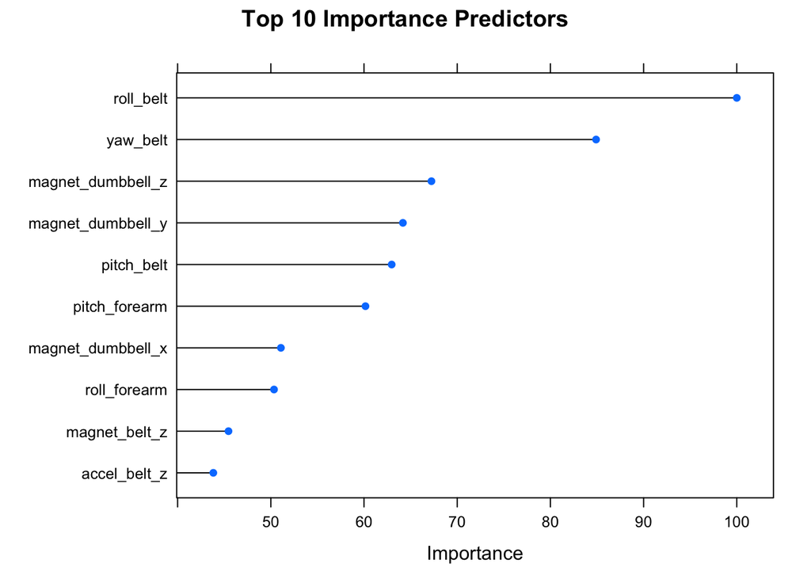

```r
plot(varImp(modFit2), top = 10, main = "Top 10 Importance Predictors")
```

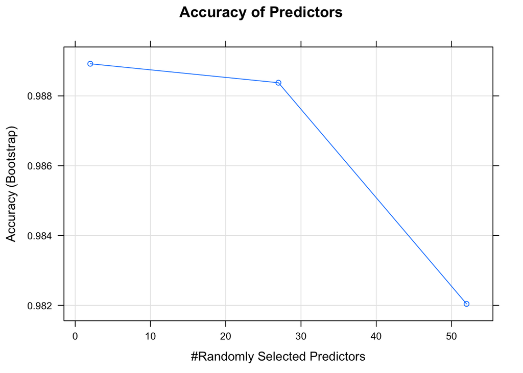

```r
#Accuracy of Predictors
plot(modFit2, main = "Accuracy of Predictors")
```

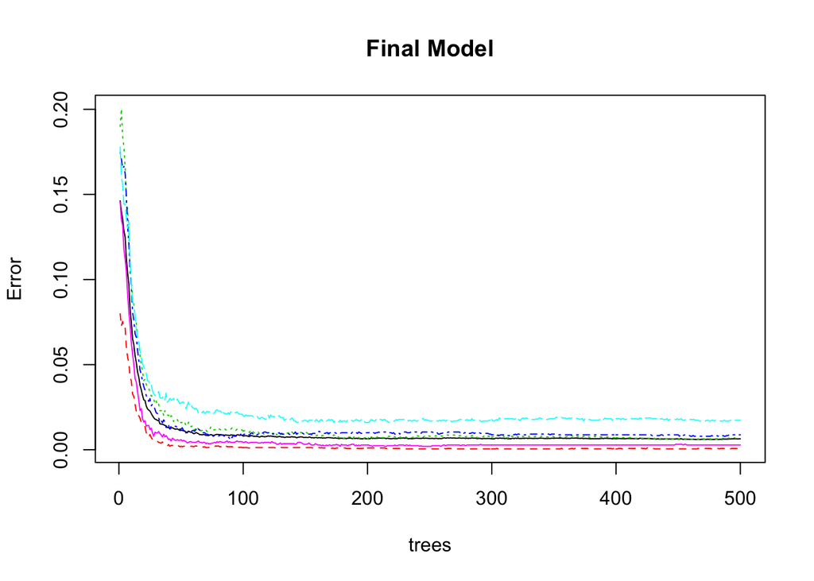

```r
#Plot of Errors
plot(modFit2$finalModel, main = "Final Model")
```

# Conclusion

The aim of this project is to create an accurate prediction model on various way to condcut weightlifting excercises using data collected through accelerometers. The final random forest model appears to be extremely accurate.